# Workshop: The Foundations: Regression with Actuarial Applications

Instructor: Edward (Jed) Frees

October 05, 2024

**VIII Simposio Internacional de Actuaria**

# About the Course

Modern machine learning tools are founded on classical regression principles. Participants in this course will receive an exposure, both theoretical and practical, to regression tools. This course will provide participants with a springboard to further their studies to gain a deep understanding of machine learning approaches.

The format of the course will consist of alternating between presentations of the underlying principles and practical applications. In a typical block, the instructor will spend 45 minutes reviewing the key mathematical underpinnings. This will be followed by a 45 minute block of time in which participants will actively explore a selected case study. Thus, it is anticipated that participants will bring a laptop with the statistical package “R” installed to the workshop. (Sharing a laptop with a colleague is also a great way to learn.)

**Seminar Preparation**. To prepare for the seminar, many participants will wish to review `R` code available at the website

[Online Tutorial on Regression Modeling with Actuarial and Financial Applications](https://ewfreesres.github.io/RegressModel/index.html).

This site employs interactive “Datacamp” style exercises.

**Target Audience**: Practicing actuaries, students, and educators interested in exposure to the foundations of insurance analytics.

**Keywords and Phrases**: Insurance analytics, ratemaking, statistical distributions, estimation and model selection, regression analysis.

# Detailed Schedule

$${\small
\begin{array}{l | l} \hline
\text{9:00-9:20 am} &\text{Welcome by the Sponsors, Introduction to the workshop,} \\
&~~~~\text{ How it will work, What you can get out of it.} \\ \hline
\text{9:20-10:00 am} &\text{Topic 1. Introduction to Analytics} \\
\text{10:00-10:30 am} &\text{Participants will explore features that influence} \\
&~~~~\text{prices of term life policies} \\
\text{10:30-11:00 am} &\text{Coffee Break} \\\hline
\text{11:00-11:45 am} &\text{Topic 2. Regression and Linear Models} \\
&~~~~\text{ with an Emphasis on Prediction} \\
\text{11:45-12:30} &\text{Participants will explore health expenditure data} \\
\text{12:30-2:00 pm} &\text{Lunch} \\\hline
\text{2:00-2:45 pm} &\text{Topic 3. Logistic Regression and Generalized Linear Models} \\
\text{2:45-3:30 pm} &\text{Participants will explore health expenditure data} \\
\text{3:30-4:00 pm} &\text{Break} \\\hline
\text{4:00-4:20 pm} &\text{Topic 4. Predictive Modeling: Frequency-Severity Models} \\
\text{4:20-4:50 pm} &\text{Participants will explore automobile data for pricing purposes} \\
\text{4:50-5:00 pm} &\text{Wrap-Up} \\\hline
\end{array}
}$$

Summaries of the theory and the cases are drawn from three sources written by the instructor:

- *Regression Modeling with Actuarial and Financial Applications*, Cambridge University Press (2010).
- *Predictive Modeling Applications in Actuarial Science, Volume 1*, Cambridge University Press (2014).
- [*Loss Data Analytics, Edition Two*](https://openacttexts.github.io/LDAVer2/index.html) (2024).

Participants need not purchase these books for the workshop. The sources are provided for your information.

A group of volunteers is working to make available a Spanish translation of the first book that will be free and available online. See our current progress at [*Modelado de Regresión con Aplicaciones Actuariales y Financieras*](https://openacttextdev.github.io/RegressionSpanish/index.html).

# About the Instructor

##### **About the Instructor**

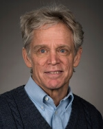

Edward (Jed) Frees is a Fellow of the American Statistical Association and a former Fellow of the Society of Actuaries. He served as founding chairperson of the Society of Actuaries’ Education and Research Section as well as a member of the Board of Directors of the Society of Actuaries; he has also served as a Trustee of the Actuarial Foundation. Professor Frees served as an actuarial representative to the Social Security Advisory Board’s Technical Panel on Methods and Assumptions. Professor Frees was the Editor and is currently on Honorary Advisory Boards for the *North American Actuarial Journal* and the *Annals of Actuarial Science*. He is also an Associate Editor for *Insurance: Mathematics and Economics*.

Professor Frees is an emeritus professor at the University of Wisconsin-Madison and was a professor of actuarial studies with the Australian National University. He is

- the editor of the Spanish version of the open actuarial textbook, [Loss Data Analytics](https://openacttexts.github.io/LDASpanish/), is
- working with a group to provide a (free) Spanish translation of his regression modeling book, and is
- currently wrapping up his latest book, entitled [Constructing Insurable Risk Portfolios](https://users.ssc.wisc.edu/~jfrees/InsurableRisks/).

You can contact Jed at jfrees@bus.wisc.edu. See the [Frees Research Website](https://sites.google.com/a/wisc.edu/jed-frees/) for more information.

# Course Syllabus and Additional Resources

As we get closer to the workshop, additional information about the course will be posted, including slides/overheads, data, and sample statistical (`R`) code.